# Skift i opbakningen til atomkraft

Søren Damsbo-Svendsen  
Postdoc  
Institut for Statskundskab  
Københavns Universitet

27. maj 2025

## Kontekst: atomkraft og klima

- **52 %** af danskerne er *bekymrede* over klimaforandringernes konsekvenser  
  (*Megafon 2025*)
  - 60 % i 2022
- **Klima** oversteg alle andre emner ved både FV19 og FV22*
  - ca. 50 % nævnte *klima* som et af de vigtigste emner
  - ca. 75 % enige i, at *klima* er vor tids største udfordring
- **Atomkraft** er i 2025 en del af *klimadebatten*

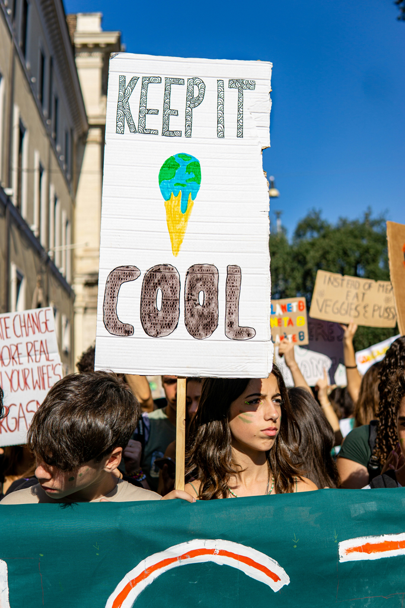

## Opbakning til atomkraft

> Det bliver nødvendigt at indføre atomkraft, hvis Danmark skal klare fremtidens energibehov
- Hvad betyder det at *‘indføre’* atomkraft?
- Hvor stort er *‘fremtidens energibehov’*? Hvornår?
- Hvor *effektivt* er atomkraft vs. alternativer
- Hvor godt kan man *lide* atomkraft vs. alternativer
- **→ Opbakning til atomkraft:**
  - *helt/delvist enig (%)*

[figure not shown]

*Valgundersøgelsen 2022*

## Opbakning til atomkraft i 1981 → 2022

[figure not shown]

## Opbakning til atomkraft i 1981 → 2022

[figure not shown]

## Opbakning til atomkraft i fem generationer

> Det bliver nødvendigt at indføre atomkraft, hvis Danmark skal klare fremtidens energibehov
- **Ideologi:** selvplacering på venstre-højre-skala (0-10)
- **Fem generationer**:

| Generation | Fødselsår | Alder FV81 | Alder FV22 |
| --- | --- | --- | --- |
| Mellemkrigsgenerationen | 1918-1945 | 36-63 år | 77-104 år |
| 68’er generationen | 1946-1959 | 22-35 år | 63-76 år |
| Generation X | 1960-1974 | 18-21 år | 48-62 år |
| Millennials | 1975-1990 |  | 32-47 år |
| Generation Z | 1991-2004 |  | 18-31 år |

## Opbakning til atomkraft i fem generationer

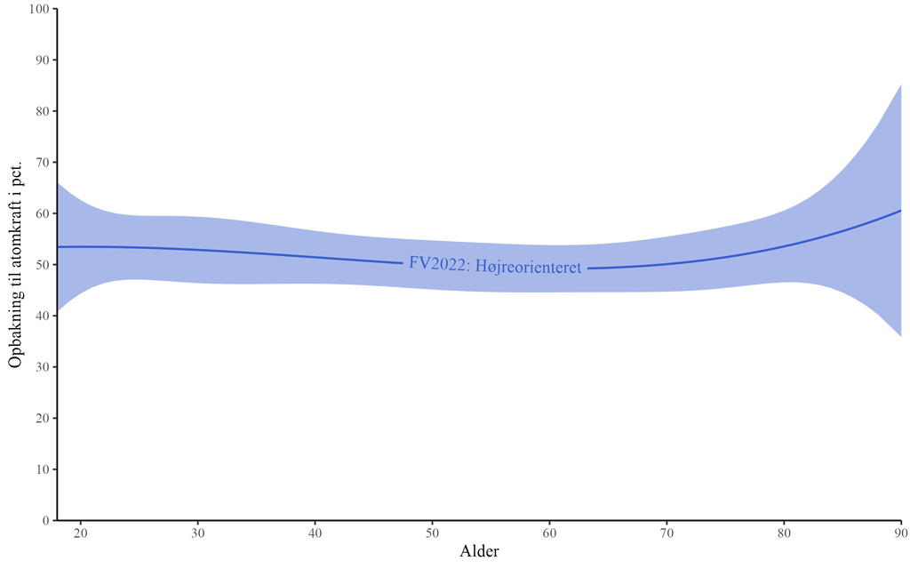

## Opbakning til atomkraft i fem generationer

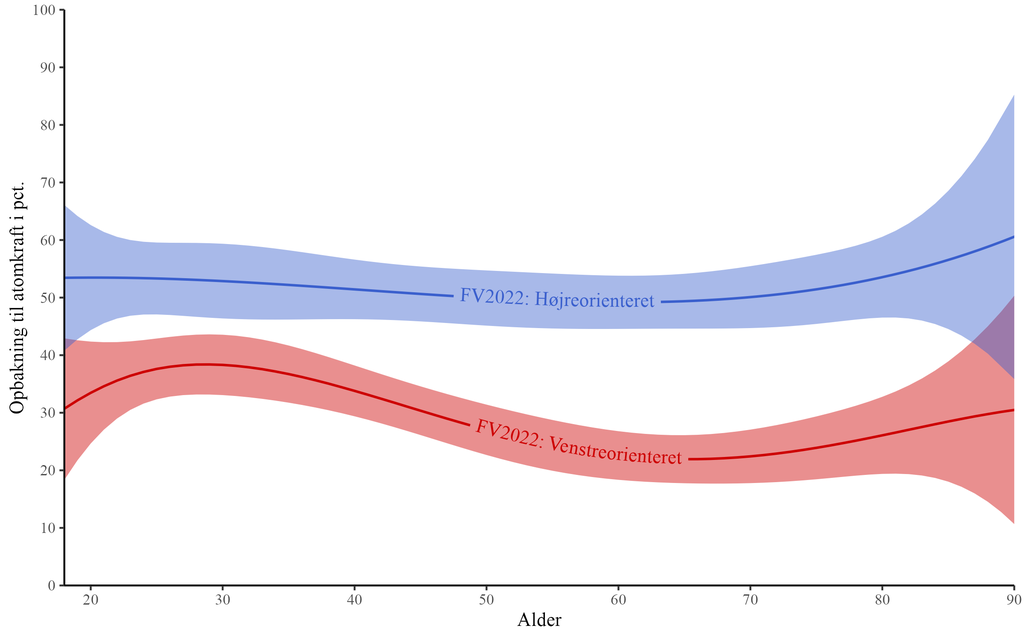

## Opbakning til atomkraft i fem generationer

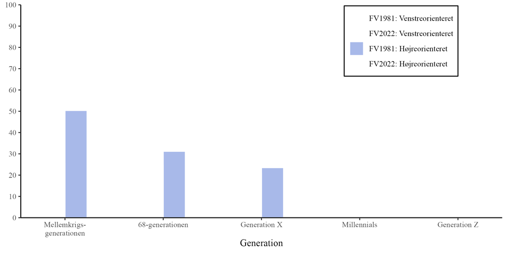

## Opbakning til atomkraft i fem generationer

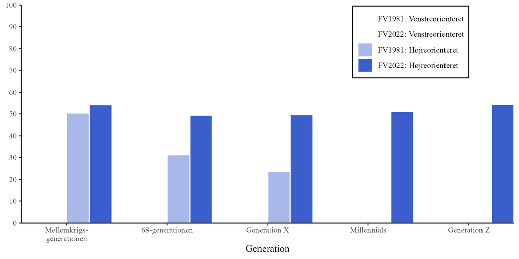

## Opbakning til atomkraft i fem generationer

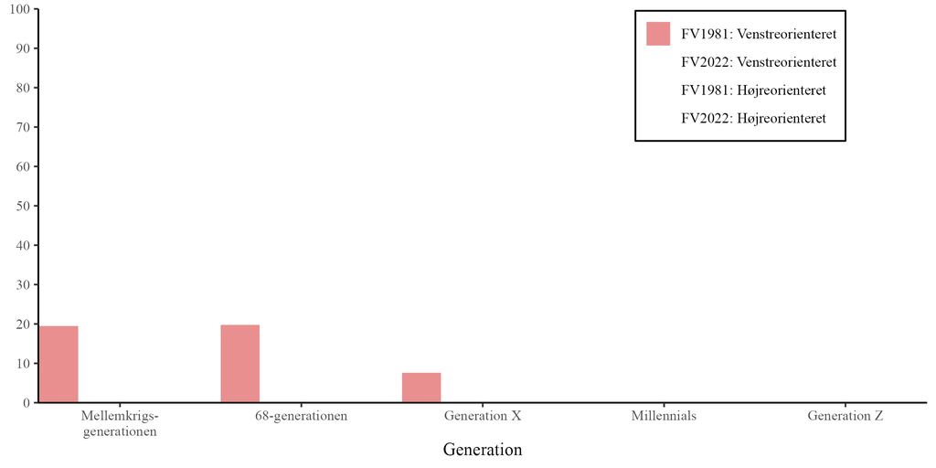

## Opbakning til atomkraft i fem generationer

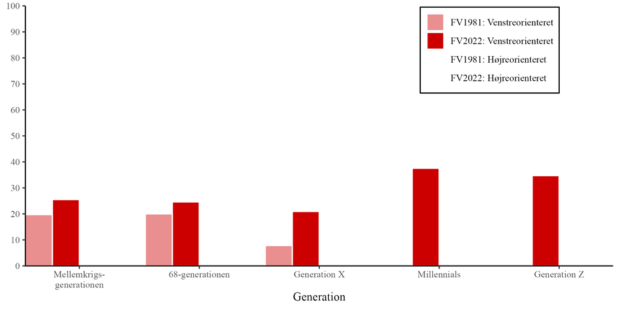

## Opbakning til atomkraft i fem generationer

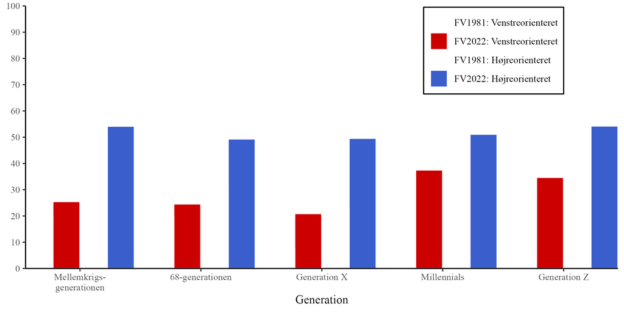

## Opbakning til atomkraft, klimaholdninger

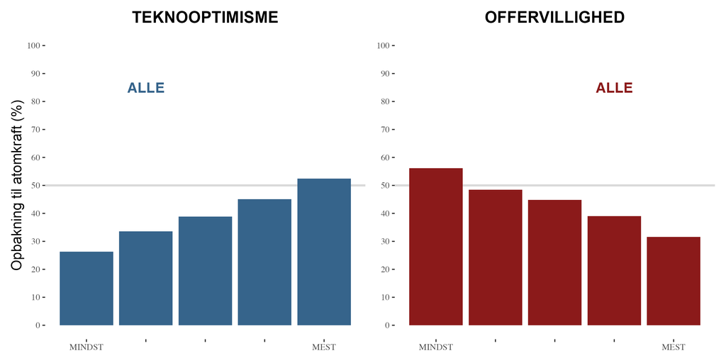

## Opbakning til atomkraft, klimaholdninger og køn

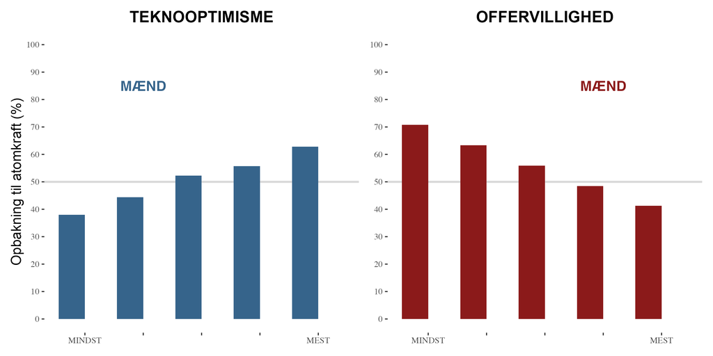

## Opbakning til atomkraft, klimaholdninger og køn

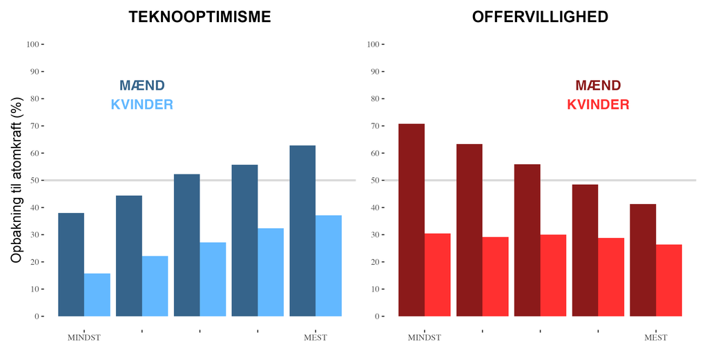

## Opbakning til atomkraft, klimaholdninger og køn

- **MEST teknooptimistisk** & MINDST offervillig:
  - **66 %** opbakning
  - og *mand*: **76 %** opbakning
- **MEST offervillig** og MINDST teknooptimistisk:
  - **21 %** opbakning
  - og *kvinde*: **16 %** opbakning

[figure not shown]

[figure not shown]

## Hvad former vores holdninger til atomkraft?

1. **Politisk socialisering**
   - atomkraftulykker, aktivisme
   - *fokusbegivenheder*
2. **Grundlæggende psykologiske træk**
3. **Ideologi**
4. **Partipolitiske signaler**
   - *mainstreaming*
5. **Teknologisk udvikling**

## Konklusion

- Et **tabu** er brudt
  - *opbakning*: 31 % → **44 %**
  - *modstand*: 48 % → **24 %**
- Men markante **skillelinjer**
  - befolkningsgrupper
  - ideologi og klimapolitiske holdninger
  - potentielt polariserende emne
- Samlet set tegn på **stigende opbakning**  
  til (at undersøge mulighederne for) **atomkraft**

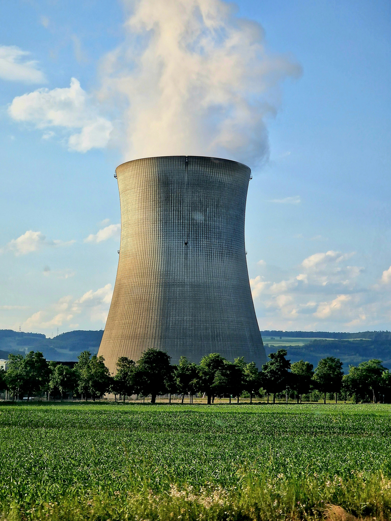